# Comparison of Sex Ratios

| Site | Sex | freq |
| --- | --- | --- |
| Foster Cove | F | 13 |
| Foster Cove | M | 31 |
| Foster Cove | N/A | 10 |
| Green Hill Pond | F | 2 |
| Green Hill Pond | M | 11 |
| Green Hill Pond | N/A | 53 |
| Narrow River | F | 3 |
| Narrow River | M | 15 |
| Narrow River | N/A | 37 |

| natural$Site | natural$Shell_Length_mm |
| --- | --- |
| Foster Cove | 58.98148 |
| Green Hill Pond | 72.19697 |
| Narrow River | 57.20000 |

## Linear Regression

First, lets determine if oyster size drives gender probability

Pobably easiest to visualize this by binning it

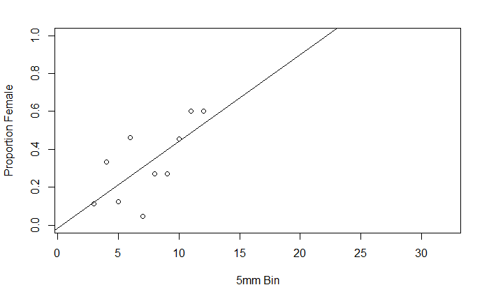

```r
gender_result <- subset(gender_dat, Sex != "N/A")
# min = 33; max = 187
bin_vector <- seq(30, 190, 5)
gender_result$Bin <- .bincode(gender_result$Shell_Length_mm, bin_vector)
bin_rat <- count(gender_result, vars = c("Bin","Sex"))
bin_rat <- reshape(bin_rat, timevar = "Sex", idvar = "Bin", direction = "wide")
colnames(bin_rat) <- c("Bin", "Male","Female")
bin_rat$FM_Ratio <- bin_rat$Female/bin_rat$Male
bin_rat$Prop_Female <- bin_rat$Female/(bin_rat$Female + bin_rat$Male)
plot(bin_rat$Prop_Female ~ bin_rat$Bin,
     ylim = c(0,1), ylab = "Proportion Female", xlab = "5mm Bin")
abline(lm(bin_rat$Prop_Female ~ bin_rat$Bin))
```

Clearly, gender is a function of size. Whether or not it is correlated linearly is uncertain given the sample size.

I think we can do better with a logistic regression.

## Binomial Logistic Regression

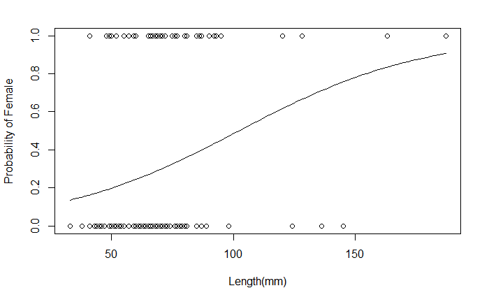

```r
gender_result$Sex <- factor(gender_result$Sex)
gender_result$Sex_Binom <- ifelse(gender_result$Sex == "M", 0, 1)
g <- glm(Sex_Binom ~ Shell_Length_mm, family = binomial, gender_result)
plot(gender_result$Shell_Length_mm, gender_result$Sex_Binom,
     xlab = "Length(mm)", ylab = "Probability of Female")
curve(predict(g, data.frame(Shell_Length_mm = x), type="resp"),add=TRUE)
```

It appears that low n and distribution of oysters across length do not give this analysis much power. This analysis may be very useful study is performed in the future.

Perhaps the correlation is stronger with Tissue wt? (may investigate in the future)

Check mean and median oyster lengths across treatments to determine whether length can confound data

```r
length_aggregates_mean <-aggregate(gender_result$Shell_Length_mm ~ gender_result$Site, FUN = mean)
colnames(length_aggregates_mean) <- c("Site","Mean.Length")
length_aggregates_median <- aggregate(gender_result$Shell_Length_mm ~ gender_result$Site, FUN = median)
colnames(length_aggregates_median) <- c("Site","Median.Length")
length_aggregates_se <- aggregate(gender_result$Shell_Length_mm ~ gender_result$Site, FUN = se)
colnames(length_aggregates_se) <- c("Site","SE")
length_aggregates <- merge(length_aggregates_mean, length_aggregates_median, by = "Site")
length_aggregates <- merge(length_aggregates, length_aggregates_se, by = "Site")
length_aggregates
```

| Site | Mean.Length | Median.Length | SE |
| --- | --- | --- | --- |
| Foster Cove | 57.93182 | 58.0 | 1.293339 |
| Green Hill Pond | 70.61538 | 68.0 | 3.288555 |
| Narrow River | 58.00000 | 60.5 | 2.916036 |
| Ninigret Aquaculture | 64.50000 | 64.5 | 1.500000 |
| Ninigret FHE | 58.04762 | 55.0 | 2.852297 |
| RWU | 75.80000 | 74.0 | 1.267090 |
| Town Pond | 129.71429 | 128.0 | 8.357245 |
| Winnapaug Aquaculture | 67.92308 | 68.0 | 1.253004 |
| Winnapaug EQIP | 103.60000 | 90.0 | 21.500233 |

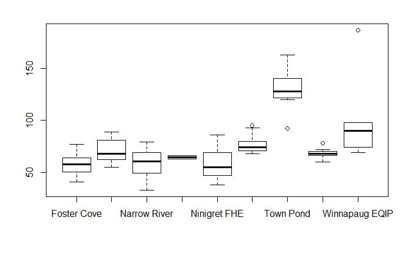

```r
boxplot(gender_result$Shell_Length_mm ~ gender_result$Site)
```

# Gender Ratio on Natural (Foster Cove) vs. FHE Reefs

Dylan’s collected data is hard to decipher for this set. It appears that many Foster Cove oysters do not come from a quadrat. Will treat entire treatment as one sample, so no analysis power, really.

The smallest oyster sampled was 38mm, so no oysters should be recent recruits

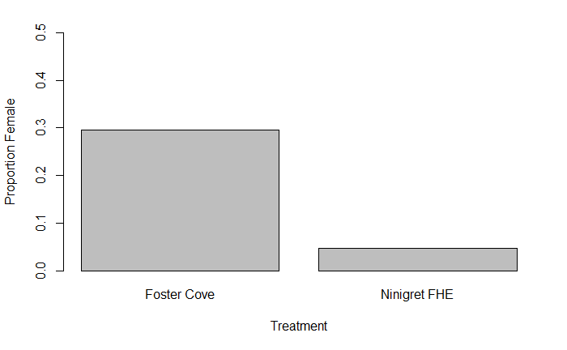

```r
ninigret <- subset(gender_result, Site == "Foster Cove" | Site == "Ninigret FHE")
ninigret_ratios <- aggregate(ninigret$Sex_Binom ~ ninigret$Site, FUN = mean)
colnames(ninigret_ratios) <- c("Site","Proportion.Female")
barplot(height = ninigret_ratios$Proportion.Female, names.arg = ninigret_ratios$Site,
        xlab = "Treatment", ylab = "Proportion Female", axes = TRUE,
        ylim = c(0,.5))
```

Results show that FC has a larger proportion of females. This study contains small sample size and is only a preliminary, exploratory study. Future work would shed more light on this imbalance and could help answer the lack of recruitment conundrum.

### Calculate N

```r
count(ninigret, vars = "Culture")
```

| Culture | freq |
| --- | --- |
| FHE | 21 |
| Natural | 44 |